# Results Section 4: Sharing of ESCrEs provides additional support for prolonged colonization

Kyle Gontjes

2026-10-26

# Environment

```r
#Packages
packages <- c("tidyverse",'kableExtra','tableone','ggVennDiagram')

#Load Packages
invisible(lapply(packages,library,character.only=T,quietly=T))

# Source library
source("./lib/consistent_themes.R")
source("./lib/common_functions.R")

# Print environment
set.seed(45)
Sys.info()
```

```
                                                                                               sysname
                                                                                              "Darwin"
                                                                                               release
                                                                                              "27.0.0"
                                                                                               version
"Darwin Kernel Version 27.0.0: Tue Aug 11 21:06:40 PDT 2026; root:xnu-13432.1.9~1/RELEASE_ARM64_T6050"
                                                                                              nodename
                                                                                "mac-k76xf3g5yq.local"
                                                                                               machine
                                                                                               "arm64"
                                                                                                 login
                                                                                                "root"
                                                                                                  user
                                                                                            "kgontjes"
                                                                                        effective_user
                                                                                            "kgontjes"
```

# Get list of index positive households

```
[1] "Number of subjects with index specimens positive: 31"
```

```
[1] "Proportion of subjects with index specimens positive: 0.775"
```

# Three case patients had episode of sharing of ESBL genes

```
[1] "Strain vs. ESCrE gene sharing"
```

```
, , Species-level = 0

      ESCrE genes
Strain  0  1
     0 11  0
     1  0  0

, , Species-level = 1

      ESCrE genes
Strain  0  1
     0  1  3
     1  0 16
```

```
                                 Variable Overall (n=31) Not same strain (n=15)
2 index_at_1_and_or_2_ESCrE_genes = 1 (%)      19 (61.3)               3 (20.0)
  Same strain (n=16) p-value
2         16 (100.0)  <0.001
```

# How many were linked by plasmid?

```
[1] "Strain vs. Plasmid-linked ESCrE genes"
```

```
      Plasmid-linked ESCrE
Strain  0  1
     0 14  1
     1  9  7
```

```
[1] "ESCrE gene persistence vs. Plasmid-linked ESCrE genes"
```

```
           Plasmid-linked ESCrE
ESCrE genes  0  1
          0 12  0
          1 11  8
```

## Eight linked to plasmid

### One different strain cases

[[1]]

| household | genomic_id | Species_ST_cluster | visit | plasmids | bla_genes | ESCrE_genes | ESCrE_plasmidic_genes | bla_chromosome_genes | ESCrE_chromosome_genes | ESCrE_plasmid_genes | bla_plasmids | ESCrE_plasmids |
| --- | --- | --- | --- | --- | --- | --- | --- | --- | --- | --- | --- | --- |
| 1H | MERLIN_288 | Escherichia coli ST 69 Singleton | 0 | AA277;AA337;AA474;AA553;AA579;AA619;AA977;AC431;novel_79f30b0d6dbdbf76081706ab79ee0ca0 | blaCTX-M-15;blaEC-8* | blaCTX-M-15;blaEC-8* | blaCTX-M-15 | blaEC-8* | blaEC-8* | blaCTX-M-15 | AA474 | AA474 |
| 1H | MERLIN_284 | Klebsiella pneumoniae ST 45 Cluster 1 | 1 | AA031;AA110;AA123;AA277;AB531;AC082;AD094 | blaCTX-M-15;blaSHV-1?;blaTEM-1?*;blaTEM-105?* | blaCTX-M-15 | blaCTX-M-15 |  |  | blaCTX-M-15 | AA031;AA277 | AA277 |
| 1H | MERLIN_268 | Escherichia coli ST 6321 Cluster 1 | 1 | AA110;AA378;AA474;AA579;AA619;AA977;AB685;AC431 | blaCTX-M-15;blaEC-8*;blaTEM-1? | blaCTX-M-15;blaEC-8* | blaCTX-M-15 | blaEC-8* | blaEC-8* | blaCTX-M-15 | AA378;AA474 | AA378 |
| 1H | MERLIN_271 | Klebsiella pneumoniae ST 45 Cluster 1 | 2 | AA277;AB183;AB531;AE974 | blaCTX-M-15;blaTEM-1?*;blaTEM-105?* | blaCTX-M-15 | blaCTX-M-15 |  |  | blaCTX-M-15 | AA277 | AA277 |
| 1H | MERLIN_272 | Escherichia coli ST 6321 Cluster 1 | 2 | AA110;AA378;AA552;AA579;AA619;AA977;AB685;AC026 | blaCTX-M-15;blaEC-8* | blaCTX-M-15;blaEC-8* | blaCTX-M-15 | blaEC-8* | blaEC-8* | blaCTX-M-15 | AC026 | AC026 |
| 1H | MERLIN_173 | Proteus mirabilis ST Unknown Singleton | 3 |  |  |  |  |  |  |  |  |  |

### Seven same strain cases

[[1]]

| household | genomic_id | Species_ST_cluster | visit | plasmids | bla_genes | ESCrE_genes | ESCrE_plasmidic_genes | bla_chromosome_genes | ESCrE_chromosome_genes | ESCrE_plasmid_genes | bla_plasmids | ESCrE_plasmids |
| --- | --- | --- | --- | --- | --- | --- | --- | --- | --- | --- | --- | --- |
| 72H | MERLIN_201 | Escherichia coli ST 1193 Cluster 1 | 0 | AA171;AA174;AA190;AB443;AB685;AC748 | blaCTX-M-15;blaCTX-M-27;blaEC-5 | blaCTX-M-15;blaCTX-M-27;blaEC-5 | blaCTX-M-15;blaCTX-M-27 | blaCTX-M-15;blaEC-5 | blaCTX-M-15;blaEC-5 | blaCTX-M-27 | AA174 | AA174 |
| 72H | MERLIN_139 | Escherichia coli ST 1193 Cluster 1 | 1 | AA190;AA352;AB443;AB685;AC748 | blaCTX-M-27;blaEC-5 | blaCTX-M-27;blaEC-5 | blaCTX-M-27 | blaEC-5 | blaEC-5 | blaCTX-M-27 | AA352 | AA352 |
| 72H | MERLIN_192 | Escherichia coli ST 1193 Cluster 1 | 3 | AA190;AA352;AB443;AB595;AB685;AC748 | blaCTX-M-27;blaEC-5 | blaCTX-M-27;blaEC-5 | blaCTX-M-27 | blaEC-5 | blaEC-5 | blaCTX-M-27 | AA352 | AA352 |

[[2]]

| household | genomic_id | Species_ST_cluster | visit | plasmids | bla_genes | ESCrE_genes | ESCrE_plasmidic_genes | bla_chromosome_genes | ESCrE_chromosome_genes | ESCrE_plasmid_genes | bla_plasmids | ESCrE_plasmids |
| --- | --- | --- | --- | --- | --- | --- | --- | --- | --- | --- | --- | --- |
| 91H | MERLIN_200 | Escherichia coli ST 131 Cluster 5 | 0 | AA147;AA579;AA735;AA977;AB445;AB688;AC748;AE235 | blaCTX-M-15;blaEC-5*;blaOXA-1 | blaCTX-M-15;blaEC-5* | blaCTX-M-15 | blaEC-5* | blaEC-5* | blaCTX-M-15 | AA735 | AA735 |
| 91H | MERLIN_114 | Escherichia coli ST 131 Cluster 5 | 1 | AA147;AA579;AA735;AA977;AB445;AB688;AC748;AE235 | blaCTX-M-15;blaEC-5*;blaOXA-1 | blaCTX-M-15;blaEC-5* | blaCTX-M-15 | blaEC-5* | blaEC-5* | blaCTX-M-15 | AA735 | AA735 |
| 91H | MERLIN_182 | Escherichia coli ST 131 Cluster 5 | 2 | AA147;AA579;AA735;AA977;AB445;AB688;AC748;AE235 | blaCTX-M-15;blaEC-5*;blaOXA-1 | blaCTX-M-15;blaEC-5* | blaCTX-M-15 | blaEC-5* | blaEC-5* | blaCTX-M-15 | AA735 | AA735 |
| 91H | MERLIN_17 | Escherichia coli ST 131 Cluster 5 | 3 | AA147;AA579;AA735;AA977;AB445;AB688;AC748;AE235 | blaCTX-M-15;blaEC-5*;blaOXA-1 | blaCTX-M-15;blaEC-5* | blaCTX-M-15 | blaEC-5* | blaEC-5* | blaCTX-M-15 | AA735 | AA735 |

[[3]]

| household | genomic_id | Species_ST_cluster | visit | plasmids | bla_genes | ESCrE_genes | ESCrE_plasmidic_genes | bla_chromosome_genes | ESCrE_chromosome_genes | ESCrE_plasmid_genes | bla_plasmids | ESCrE_plasmids |
| --- | --- | --- | --- | --- | --- | --- | --- | --- | --- | --- | --- | --- |
| 109H | MERLIN_225 | Escherichia coli ST 1193 Cluster 2 | 0 | AA171;AA174;AA352;AA474;AA476;AA579;AB443;AB685;AB687;AC511;AC748;novel_236e327b6e945ee035c1ec7620c2e90b;novel_274ddd5d9a0e3df059f68299b2ade951;novel_814bae8c63a91243fd0f1c6e54e29348 | blaCTX-M-27;blaEC-5 | blaCTX-M-27;blaEC-5 | blaCTX-M-27 | blaEC-5 | blaEC-5 | blaCTX-M-27 | AA474 | AA474 |
| 109H | MERLIN_115 | Escherichia coli ST 1193 Cluster 2 | 1 | AA171;AA174;AA579;AB443;AB685;AC511;AC748 | blaCTX-M-27;blaEC-5 | blaCTX-M-27;blaEC-5 | blaCTX-M-27 | blaEC-5 | blaEC-5 | blaCTX-M-27 | AA171 | AA171 |
| 109H | MERLIN_193 | Escherichia coli ST 1193 Cluster 2 | 2 | AA171;AA174;AA579;AB443;AB685;AC511;AC748 | blaCTX-M-27;blaEC-5 | blaCTX-M-27;blaEC-5 | blaCTX-M-27 | blaEC-5 | blaEC-5 | blaCTX-M-27 | AA171 | AA171 |
| 109H | MERLIN_195 | Escherichia coli ST 1193 Cluster 2 | 3 | AA171;AA174;AA579;AB443;AB685;AC511;AC748 | blaCTX-M-27;blaEC-5 | blaCTX-M-27;blaEC-5 | blaCTX-M-27 | blaEC-5 | blaEC-5 | blaCTX-M-27 | AA171 | AA171 |

[[4]]

| household | genomic_id | Species_ST_cluster | visit | plasmids | bla_genes | ESCrE_genes | ESCrE_plasmidic_genes | bla_chromosome_genes | ESCrE_chromosome_genes | ESCrE_plasmid_genes | bla_plasmids | ESCrE_plasmids |
| --- | --- | --- | --- | --- | --- | --- | --- | --- | --- | --- | --- | --- |
| 130H | MERLIN_191 | Escherichia coli ST 38 Cluster 1 | 0 | AA142;AA372;AA579;AB685 | blaCTX-M-15;blaEC-8* | blaCTX-M-15;blaEC-8* | blaCTX-M-15 | blaEC-8* | blaEC-8* | blaCTX-M-15 | AA372 | AA372 |
| 130H | MERLIN_196 | Escherichia coli ST 38 Cluster 1 | 1 | AA282;AA579;AB685;AC741 | blaCMY-4;blaCTX-M-15;blaEC-8* | blaCMY-4;blaCTX-M-15;blaEC-8* | blaCMY-4;blaCTX-M-15 | blaCTX-M-15;blaEC-8* | blaCTX-M-15;blaEC-8* | blaCMY-4 | AA282 | AA282 |
| 130H | MERLIN_78 | Escherichia coli ST 38 Cluster 1 | 2 | AA282;AA579;AB685 | blaCMY-4;blaCTX-M-15;blaEC-8* | blaCMY-4;blaCTX-M-15;blaEC-8* | blaCMY-4;blaCTX-M-15 | blaCTX-M-15;blaEC-8* | blaCTX-M-15;blaEC-8* | blaCMY-4 | AA282 | AA282 |
| 130H | MERLIN_39 | Escherichia coli ST 38 Cluster 1 | 3 | AA142;AA282;AA579;AB685;AC741 | blaCMY-4;blaCTX-M-15;blaEC-8* | blaCMY-4;blaCTX-M-15;blaEC-8* | blaCMY-4;blaCTX-M-15 | blaCTX-M-15;blaEC-8* | blaCTX-M-15;blaEC-8* | blaCMY-4 | AA282 | AA282 |

[[5]]

| household | genomic_id | Species_ST_cluster | visit | plasmids | bla_genes | ESCrE_genes | ESCrE_plasmidic_genes | bla_chromosome_genes | ESCrE_chromosome_genes | ESCrE_plasmid_genes | bla_plasmids | ESCrE_plasmids |
| --- | --- | --- | --- | --- | --- | --- | --- | --- | --- | --- | --- | --- |
| 231H | MERLIN_258 | Escherichia coli ST 131 Cluster 9 | 0 | AA282;AA324 | blaCTX-M-15;blaEC-5*;blaOXA-1 | blaCTX-M-15;blaEC-5* | blaCTX-M-15 | blaEC-5* | blaEC-5* | blaCTX-M-15 | AA324 | AA324 |
| 231H | MERLIN_26 | Escherichia coli ST 131 Cluster 9 | 1 | AA282;AA324 | blaCTX-M-15;blaEC-5*;blaOXA-1 | blaCTX-M-15;blaEC-5* | blaCTX-M-15 | blaEC-5* | blaEC-5* | blaCTX-M-15 | AA324 | AA324 |
| 231H | MERLIN_73 | Escherichia coli ST 131 Cluster 9 | 2 | AA282;AA324;AA552 | blaCTX-M-15;blaEC-5*;blaOXA-1 | blaCTX-M-15;blaEC-5* | blaCTX-M-15 | blaEC-5* | blaEC-5* | blaCTX-M-15 | AA324 | AA324 |

[[6]]

| household | genomic_id | Species_ST_cluster | visit | plasmids | bla_genes | ESCrE_genes | ESCrE_plasmidic_genes | bla_chromosome_genes | ESCrE_chromosome_genes | ESCrE_plasmid_genes | bla_plasmids | ESCrE_plasmids |
| --- | --- | --- | --- | --- | --- | --- | --- | --- | --- | --- | --- | --- |
| 293H | MERLIN_64 | Escherichia coli ST 131 Cluster 2 | 0 | AA171;AA977;AB685 | blaCTX-M-27;blaEC-5* | blaCTX-M-27;blaEC-5* | blaCTX-M-27 | blaEC-5* | blaEC-5* | blaCTX-M-27 | AA171 | AA171 |
| 293H | MERLIN_72 | Escherichia coli ST 131 Cluster 2 | 1 | AA171;AA977;AB685 | blaCTX-M-27;blaEC-5* | blaCTX-M-27;blaEC-5* | blaCTX-M-27 | blaEC-5* | blaEC-5* | blaCTX-M-27 | AA171 | AA171 |
| 293H | MERLIN_164 | Escherichia coli ST 131 Cluster 2 | 2 | AA171;AA977;AB685 | blaCTX-M-27;blaEC-5* | blaCTX-M-27;blaEC-5* | blaCTX-M-27 | blaEC-5* | blaEC-5* | blaCTX-M-27 | AA171 | AA171 |
| 293H | MERLIN_159 | Escherichia coli ST 131 Cluster 2 | 3 | AA171;AA977;AB685 | blaCTX-M-27;blaEC-5* | blaCTX-M-27;blaEC-5* | blaCTX-M-27 | blaEC-5* | blaEC-5* | blaCTX-M-27 | AA171 | AA171 |

[[7]]

| household | genomic_id | Species_ST_cluster | visit | plasmids | bla_genes | ESCrE_genes | ESCrE_plasmidic_genes | bla_chromosome_genes | ESCrE_chromosome_genes | ESCrE_plasmid_genes | bla_plasmids | ESCrE_plasmids |
| --- | --- | --- | --- | --- | --- | --- | --- | --- | --- | --- | --- | --- |
| 445H | MERLIN_155 | Klebsiella pneumoniae ST 15 Cluster 1 | 0 | AA024;AA277;AA810;AB687;AD092;AG600;novel_c4cbcd9229542950b70cf3873d91ead5 | blaCTX-M-15;blaSHV-28;blaTEM-1 | blaCTX-M-15 | blaCTX-M-15 | blaSHV-28 |  | blaCTX-M-15 | AA277 | AA277 |
| 445H | MERLIN_209 | Klebsiella pneumoniae ST 15 Cluster 1 | 2 | AA277;AA452;AB687;AG600 | blaCTX-M-15;blaSHV-28;blaTEM-1 | blaCTX-M-15 | blaCTX-M-15 | blaSHV-28 |  | blaCTX-M-15 | AA452 | AA452 |
| 445H | MERLIN_234 | Klebsiella pneumoniae ST 15 Cluster 1 | 3 | AA450;AA554;AB687 | blaCTX-M-15;blaSHV-28;blaTEM-1 | blaCTX-M-15 | blaCTX-M-15 | blaSHV-28 |  | blaCTX-M-15 | AA554 | AA554 |

[[1]]

| household | genomic_id | Species_ST_cluster | visit | plasmids | bla_genes | ESCrE_genes | ESCrE_plasmidic_genes | bla_chromosome_genes | ESCrE_chromosome_genes | ESCrE_plasmid_genes | bla_plasmids | ESCrE_plasmids |
| --- | --- | --- | --- | --- | --- | --- | --- | --- | --- | --- | --- | --- |
| 100H | MERLIN_266 | Escherichia coli ST 973 Singleton | 0 | AA474;AA579 | blaCMY-2;blaEC-8* | blaCMY-2;blaEC-8* | blaCMY-2 | blaEC-8* | blaEC-8* | blaCMY-2 | AA474 | AA474 |
| 100H | MERLIN_150 | Escherichia coli ST 38 Cluster 2 | 2 | AA337;AA579;AA977;AB687 | blaCTX-M-15;blaEC-8*;blaTEM-1 | blaCTX-M-15;blaEC-8* | blaCTX-M-15 | blaCTX-M-15;blaEC-8* | blaCTX-M-15;blaEC-8* |  | AA337 |  |
| 100H | MERLIN_128 | Escherichia coli ST 38 Cluster 2 | 3 | AA337;AA579;AA977;AB595;AB687 | blaCTX-M-15;blaEC-8*;blaTEM-1 | blaCTX-M-15;blaEC-8* | blaCTX-M-15 | blaCTX-M-15;blaEC-8* | blaCTX-M-15;blaEC-8* |  | AA337 |  |

[[2]]

| household | genomic_id | Species_ST_cluster | visit | plasmids | bla_genes | ESCrE_genes | ESCrE_plasmidic_genes | bla_chromosome_genes | ESCrE_chromosome_genes | ESCrE_plasmid_genes | bla_plasmids | ESCrE_plasmids |
| --- | --- | --- | --- | --- | --- | --- | --- | --- | --- | --- | --- | --- |
| 126H | MERLIN_190 | Escherichia coli ST 4118 Cluster 1 | 0 | AA474;AA581 | blaCMY-2;blaEC-8*;blaTEM-1 | blaCMY-2;blaEC-8* | blaCMY-2 | blaCMY-2;blaEC-8* | blaCMY-2;blaEC-8* |  | AA474 |  |
| 126H | MERLIN_1 | Escherichia coli ST 4118 Cluster 1 | 1 | AA474;AA581 | blaCMY-2;blaEC-8*;blaTEM-1 | blaCMY-2;blaEC-8* | blaCMY-2 | blaCMY-2;blaEC-8* | blaCMY-2;blaEC-8* |  | AA474 |  |
| 126H | MERLIN_79 | Escherichia coli ST 4118 Cluster 1 | 2 | AA474;AA581;AA747 | blaCMY-2;blaEC-8*;blaTEM-1 | blaCMY-2;blaEC-8* | blaCMY-2 | blaCMY-2;blaEC-8* | blaCMY-2;blaEC-8* |  | AA474 |  |
| 126H | MERLIN_38 | Escherichia coli ST 4118 Cluster 1 | 3 | AA474;AA581 | blaCMY-2;blaEC-8*;blaTEM-1 | blaCMY-2;blaEC-8* | blaCMY-2 | blaCMY-2;blaEC-8* | blaCMY-2;blaEC-8* |  | AA474 |  |

[[3]]

| household | genomic_id | Species_ST_cluster | visit | plasmids | bla_genes | ESCrE_genes | ESCrE_plasmidic_genes | bla_chromosome_genes | ESCrE_chromosome_genes | ESCrE_plasmid_genes | bla_plasmids | ESCrE_plasmids |
| --- | --- | --- | --- | --- | --- | --- | --- | --- | --- | --- | --- | --- |
| 198H | MERLIN_10 | Escherichia coli ST 131 Cluster 1 | 0 | AA171;AA579;AC748 | blaCTX-M-15;blaEC-5* | blaCTX-M-15;blaEC-5* | blaCTX-M-15 | blaCTX-M-15;blaEC-5* | blaCTX-M-15;blaEC-5* |  |  |  |
| 198H | MERLIN_21 | Escherichia coli ST 131 Cluster 1 | 1 | AA190;AA336;AA579;AB687;AC512;AC748 | blaCTX-M-15;blaEC-5* | blaCTX-M-15;blaEC-5* | blaCTX-M-15 | blaCTX-M-15;blaEC-5* | blaCTX-M-15;blaEC-5* |  |  |  |
| 198H | MERLIN_40 | Escherichia coli ST 131 Cluster 1 | 2 | AA336;AA579;AC512;AC748 | blaCTX-M-15;blaEC-5* | blaCTX-M-15;blaEC-5* | blaCTX-M-15 | blaCTX-M-15;blaEC-5* | blaCTX-M-15;blaEC-5* |  |  |  |
| 198H | MERLIN_91 | Escherichia coli ST 131 Cluster 1 | 3 | AA190;AA336;AA579;AC512;AC748 | blaCTX-M-15;blaEC-5* | blaCTX-M-15;blaEC-5* | blaCTX-M-15 | blaCTX-M-15;blaEC-5* | blaCTX-M-15;blaEC-5* |  |  |  |

[[4]]

| household | genomic_id | Species_ST_cluster | visit | plasmids | bla_genes | ESCrE_genes | ESCrE_plasmidic_genes | bla_chromosome_genes | ESCrE_chromosome_genes | ESCrE_plasmid_genes | bla_plasmids | ESCrE_plasmids |
| --- | --- | --- | --- | --- | --- | --- | --- | --- | --- | --- | --- | --- |
| 320H | MERLIN_82 | Escherichia coli ST 131 Cluster 4 | 0 | AA337 | blaCTX-M-15;blaEC-5* | blaCTX-M-15;blaEC-5* | blaCTX-M-15 | blaCTX-M-15;blaEC-5* | blaCTX-M-15;blaEC-5* |  |  |  |
| 320H | MERLIN_84 | Escherichia coli ST 131 Cluster 4 | 1 | AA337 | blaCTX-M-15;blaEC-5* | blaCTX-M-15;blaEC-5* | blaCTX-M-15 | blaCTX-M-15;blaEC-5* | blaCTX-M-15;blaEC-5* |  |  |  |
| 320H | MERLIN_130 | Escherichia coli ST 131 Cluster 4 | 2 | AA337 | blaCTX-M-15;blaEC-5* | blaCTX-M-15;blaEC-5* | blaCTX-M-15 | blaCTX-M-15;blaEC-5* | blaCTX-M-15;blaEC-5* |  |  |  |
| 320H | MERLIN_158 | Escherichia coli ST 131 Cluster 4 | 3 | AA337 | blaCTX-M-15;blaEC-5* | blaCTX-M-15;blaEC-5* | blaCTX-M-15 | blaCTX-M-15;blaEC-5* | blaCTX-M-15;blaEC-5* |  |  |  |
| 320H | MERLIN_157 | Escherichia coli ST 131 Cluster 4 | 3 | AA337 | blaCTX-M-15;blaEC-5* | blaCTX-M-15;blaEC-5* | blaCTX-M-15 | blaCTX-M-15;blaEC-5* | blaCTX-M-15;blaEC-5* |  |  |  |

[[5]]

| household | genomic_id | Species_ST_cluster | visit | plasmids | bla_genes | ESCrE_genes | ESCrE_plasmidic_genes | bla_chromosome_genes | ESCrE_chromosome_genes | ESCrE_plasmid_genes | bla_plasmids | ESCrE_plasmids |
| --- | --- | --- | --- | --- | --- | --- | --- | --- | --- | --- | --- | --- |
| 345H | MERLIN_86 | Escherichia coli ST 131 Cluster 8 | 0 | AA171;AA174 | blaCTX-M-15;blaEC-5* | blaCTX-M-15;blaEC-5* | blaCTX-M-15 | blaCTX-M-15;blaEC-5* | blaCTX-M-15;blaEC-5* |  |  |  |
| 345H | MERLIN_88 | Escherichia coli ST 131 Cluster 8 | 1 | AA171;AA174 | blaCTX-M-15;blaEC-5* | blaCTX-M-15;blaEC-5* | blaCTX-M-15 | blaCTX-M-15;blaEC-5* | blaCTX-M-15;blaEC-5* |  |  |  |
| 345H | MERLIN_145 | Escherichia coli ST 131 Cluster 8 | 2 | AA171;AA174 | blaCTX-M-15;blaEC-5* | blaCTX-M-15;blaEC-5* | blaCTX-M-15 | blaCTX-M-15;blaEC-5* | blaCTX-M-15;blaEC-5* |  |  |  |
| 345H | MERLIN_RE_3 | Escherichia coli ST 131 Cluster 8 | 3 | AA171;AA174 | blaCTX-M-15;blaEC-5* | blaCTX-M-15;blaEC-5* | blaCTX-M-15 | blaCTX-M-15;blaEC-5* | blaCTX-M-15;blaEC-5* |  |  |  |

[[6]]

| household | genomic_id | Species_ST_cluster | visit | plasmids | bla_genes | ESCrE_genes | ESCrE_plasmidic_genes | bla_chromosome_genes | ESCrE_chromosome_genes | ESCrE_plasmid_genes | bla_plasmids | ESCrE_plasmids |
| --- | --- | --- | --- | --- | --- | --- | --- | --- | --- | --- | --- | --- |
| 387H | MERLIN_109 | Enterobacter hormaechei ST 78 Cluster 1 | 0 | AB040;AB169;AC542 | blaACT-24 | blaACT-24 |  | blaACT-24 | blaACT-24 |  |  |  |
| 387H | MERLIN_144 | Enterobacter hormaechei ST 78 Cluster 1 | 1 | AB040;AB169;AC542 | blaACT-24 | blaACT-24 |  | blaACT-24 | blaACT-24 |  |  |  |
| 387H | MERLIN_212 | Citrobacter sp ST Unknown Singleton | 2 |  | blaCMY-190* | blaCMY-190* |  | blaCMY-190* | blaCMY-190* |  |  |  |
| 387H | MERLIN_240 | Enterobacter hormaechei ST 78 Cluster 1 | 3 | AB040 | blaACT-24 | blaACT-24 |  | blaACT-24 | blaACT-24 |  |  |  |

[[7]]

| household | genomic_id | Species_ST_cluster | visit | plasmids | bla_genes | ESCrE_genes | ESCrE_plasmidic_genes | bla_chromosome_genes | ESCrE_chromosome_genes | ESCrE_plasmid_genes | bla_plasmids | ESCrE_plasmids |
| --- | --- | --- | --- | --- | --- | --- | --- | --- | --- | --- | --- | --- |
| 395H | MERLIN_126 | Enterobacter hormaechei ST 45 Cluster 1 | 0 | AA419;AA424;AB040 | blaACT-17;blaTEM-1 | blaACT-17 |  | blaACT-17 | blaACT-17 |  | AA424 |  |
| 395H | MERLIN_206 | Enterobacter hormaechei ST 45 Cluster 1 | 3 | AA419;AA424;AB040 | blaACT-17;blaTEM-1 | blaACT-17 |  | blaACT-17 | blaACT-17 |  | AA424 |  |

[[8]]

| household | genomic_id | Species_ST_cluster | visit | plasmids | bla_genes | ESCrE_genes | ESCrE_plasmidic_genes | bla_chromosome_genes | ESCrE_chromosome_genes | ESCrE_plasmid_genes | bla_plasmids | ESCrE_plasmids |
| --- | --- | --- | --- | --- | --- | --- | --- | --- | --- | --- | --- | --- |
| 399H | MERLIN_125 | Escherichia coli ST 131 Cluster 6 | 0 | AA337 | blaCTX-M-27;blaEC-5*;blaTEM-1 | blaCTX-M-27;blaEC-5* | blaCTX-M-27 | blaCTX-M-27;blaEC-5* | blaCTX-M-27;blaEC-5* |  | AA337 |  |
| 399H | MERLIN_175 | Escherichia coli ST 131 Cluster 6 | 1 | AA337 | blaCTX-M-27;blaEC-5*;blaTEM-1 | blaCTX-M-27;blaEC-5* | blaCTX-M-27 | blaCTX-M-27;blaEC-5* | blaCTX-M-27;blaEC-5* |  | AA337 |  |
| 399H | MERLIN_213 | Escherichia coli ST 131 Cluster 6 | 2 | AA337 | blaCTX-M-27;blaEC-5*;blaTEM-1 | blaCTX-M-27;blaEC-5* | blaCTX-M-27 | blaCTX-M-27;blaEC-5* | blaCTX-M-27;blaEC-5* |  | AA337 |  |
| 399H | MERLIN_257 | Escherichia coli ST 131 Cluster 6 | 3 | AA002;AA337;novel_6d376b67d5de7de7561485045887729d | blaCTX-M-27;blaEC-5*;blaTEM-1 | blaCTX-M-27;blaEC-5* | blaCTX-M-27 | blaCTX-M-27;blaEC-5* | blaCTX-M-27;blaEC-5* |  | AA337 |  |

[[9]]

| household | genomic_id | Species_ST_cluster | visit | plasmids | bla_genes | ESCrE_genes | ESCrE_plasmidic_genes | bla_chromosome_genes | ESCrE_chromosome_genes | ESCrE_plasmid_genes | bla_plasmids | ESCrE_plasmids |
| --- | --- | --- | --- | --- | --- | --- | --- | --- | --- | --- | --- | --- |
| 49H | MERLIN_227 | Escherichia coli ST 744 Cluster 1 | 0 | AA176;AB065;AB233;AB714;novel_360ee3544ec2ea0f520a6839fe2fd8f9 | blaCTX-M-55;blaEC;blaTEM-214 | blaCTX-M-55;blaEC | blaCTX-M-55 | blaEC | blaEC | blaCTX-M-55 | AA176;AB714 | AB714 |
| 49H | MERLIN_117 | Escherichia coli ST 744 Cluster 1 | 1 | AA175;AA176;AA327;AA473;AB065;AB233;AG658 | blaEC | blaEC |  | blaEC | blaEC |  |  |  |
| 49H | MERLIN_129 | Escherichia coli ST 744 Cluster 1 | 2 | AA175;AA327;AA474;AB065;AB233;AC770;AD312 | blaEC | blaEC |  | blaEC | blaEC |  |  |  |

[[10]]

| household | genomic_id | Species_ST_cluster | visit | plasmids | bla_genes | ESCrE_genes | ESCrE_plasmidic_genes | bla_chromosome_genes | ESCrE_chromosome_genes | ESCrE_plasmid_genes | bla_plasmids | ESCrE_plasmids |
| --- | --- | --- | --- | --- | --- | --- | --- | --- | --- | --- | --- | --- |
| 64H | MERLIN_274 | Klebsiella pneumoniae ST 323 Cluster 1 | 0 | AA276;AB045;AB049;AG456 | blaCTX-M-15;blaSHV-1;blaTEM-1 | blaCTX-M-15 | blaCTX-M-15 | blaCTX-M-15;blaSHV-1 | blaCTX-M-15 |  | AA276 |  |
| 64H | MERLIN_116 | Klebsiella pneumoniae ST 323 Cluster 1 | 2 | AA276;AB045;AC302 | blaCTX-M-15;blaSHV-1;blaTEM-1 | blaCTX-M-15 | blaCTX-M-15 | blaCTX-M-15;blaSHV-1 | blaCTX-M-15 |  | AA276 |  |
| 64H | MERLIN_287 | Klebsiella pneumoniae ST 323 Cluster 1 | 3 | AA276;AB045 | blaCTX-M-15;blaSHV-1;blaTEM-1 | blaCTX-M-15 | blaCTX-M-15 | blaCTX-M-15;blaSHV-1 | blaCTX-M-15 |  | AA276 |  |

# Summary: Four cases where prolonged colonization at species-level found, but not strain-level

## One case was different sequence type but no shared ESCrE gene (i.e., likely acquisition)

[[1]]

| household | genomic_id | Species_ST_cluster | visit | plasmids | bla_genes | ESCrE_genes | ESCrE_plasmidic_genes | bla_chromosome_genes | ESCrE_chromosome_genes | ESCrE_plasmid_genes | bla_plasmids | ESCrE_plasmids |
| --- | --- | --- | --- | --- | --- | --- | --- | --- | --- | --- | --- | --- |
| 182H | MERLIN_8 | Citrobacter portucalensis ST Unknown Singleton | 0 |  | blaCMY-13* | blaCMY-13* |  | blaCMY-13* | blaCMY-13* |  |  |  |
| 182H | MERLIN_34 | Citrobacter portucalensis ST 13 Singleton | 2 |  | blaCMY-25* | blaCMY-25* |  | blaCMY-25* | blaCMY-25* |  |  |  |

# Cases explained by ESCrE persistence but not strain

### Novel strain acquisition:

#### 1. 100H - Different E. coli ST - Linked by blaEC-8, but this was on the chromosome of both genomes…

#### 2. 169H- Different E. coli ST 131 clusters - Linked by CTX-M-15 and blaEC-5*. While blaEC-5 was chromosomal, CTX-M-15 was found on plasmid in 1 isolate, suggestive of HGT and/or co-colonization…

### Plasmid sharing:

, , Plasmid associated = 0

```
  ESCrE gene
```

Strain 0 1 0 12 2 1 0 9

, , Plasmid associated = 1

```
  ESCrE gene
```

Strain 0 1 0 0 1 1 0 7

[[1]]

| household | genomic_id | Species_ST_cluster | visit | plasmids | bla_genes | ESCrE_genes | ESCrE_plasmidic_genes | bla_chromosome_genes | ESCrE_chromosome_genes | ESCrE_plasmid_genes | bla_plasmids | ESCrE_plasmids |
| --- | --- | --- | --- | --- | --- | --- | --- | --- | --- | --- | --- | --- |
| 100H | MERLIN_266 | Escherichia coli ST 973 Singleton | 0 | AA474;AA579 | blaCMY-2;blaEC-8* | blaCMY-2;blaEC-8* | blaCMY-2 | blaEC-8* | blaEC-8* | blaCMY-2 | AA474 | AA474 |
| 100H | MERLIN_150 | Escherichia coli ST 38 Cluster 2 | 2 | AA337;AA579;AA977;AB687 | blaCTX-M-15;blaEC-8*;blaTEM-1 | blaCTX-M-15;blaEC-8* | blaCTX-M-15 | blaCTX-M-15;blaEC-8* | blaCTX-M-15;blaEC-8* |  | AA337 |  |
| 100H | MERLIN_128 | Escherichia coli ST 38 Cluster 2 | 3 | AA337;AA579;AA977;AB595;AB687 | blaCTX-M-15;blaEC-8*;blaTEM-1 | blaCTX-M-15;blaEC-8* | blaCTX-M-15 | blaCTX-M-15;blaEC-8* | blaCTX-M-15;blaEC-8* |  | AA337 |  |

[[2]]

| household | genomic_id | Species_ST_cluster | visit | plasmids | bla_genes | ESCrE_genes | ESCrE_plasmidic_genes | bla_chromosome_genes | ESCrE_chromosome_genes | ESCrE_plasmid_genes | bla_plasmids | ESCrE_plasmids |
| --- | --- | --- | --- | --- | --- | --- | --- | --- | --- | --- | --- | --- |
| 169H | MERLIN_9 | Escherichia coli ST 131 Cluster 1 | 0 | AA171;AA172;AA579;AB687;AC748 | blaCTX-M-15;blaEC-5* | blaCTX-M-15;blaEC-5* | blaCTX-M-15 | blaCTX-M-15;blaEC-5* | blaCTX-M-15;blaEC-5* |  |  |  |
| 169H | MERLIN_24 | Escherichia coli ST 131 Cluster 11 | 2 | AA324 | blaCTX-M-15;blaEC-5*;blaOXA-1 | blaCTX-M-15;blaEC-5* | blaCTX-M-15 | blaEC-5* | blaEC-5* | blaCTX-M-15 | AA324 | AA324 |
| 169H | MERLIN_68 | Escherichia coli ST 131 Cluster 11 | 3 | AA173;AA324 | blaCTX-M-15;blaEC-5*;blaOXA-1 | blaCTX-M-15;blaEC-5* | blaCTX-M-15 | blaCTX-M-15;blaEC-5*;blaOXA-1 | blaCTX-M-15;blaEC-5* |  |  |  |

[[3]]

| household | genomic_id | Species_ST_cluster | visit | plasmids | bla_genes | ESCrE_genes | ESCrE_plasmidic_genes | bla_chromosome_genes | ESCrE_chromosome_genes | ESCrE_plasmid_genes | bla_plasmids | ESCrE_plasmids |
| --- | --- | --- | --- | --- | --- | --- | --- | --- | --- | --- | --- | --- |
| 1H | MERLIN_288 | Escherichia coli ST 69 Singleton | 0 | AA277;AA337;AA474;AA553;AA579;AA619;AA977;AC431;novel_79f30b0d6dbdbf76081706ab79ee0ca0 | blaCTX-M-15;blaEC-8* | blaCTX-M-15;blaEC-8* | blaCTX-M-15 | blaEC-8* | blaEC-8* | blaCTX-M-15 | AA474 | AA474 |
| 1H | MERLIN_284 | Klebsiella pneumoniae ST 45 Cluster 1 | 1 | AA031;AA110;AA123;AA277;AB531;AC082;AD094 | blaCTX-M-15;blaSHV-1?;blaTEM-1?*;blaTEM-105?* | blaCTX-M-15 | blaCTX-M-15 |  |  | blaCTX-M-15 | AA031;AA277 | AA277 |
| 1H | MERLIN_268 | Escherichia coli ST 6321 Cluster 1 | 1 | AA110;AA378;AA474;AA579;AA619;AA977;AB685;AC431 | blaCTX-M-15;blaEC-8*;blaTEM-1? | blaCTX-M-15;blaEC-8* | blaCTX-M-15 | blaEC-8* | blaEC-8* | blaCTX-M-15 | AA378;AA474 | AA378 |
| 1H | MERLIN_271 | Klebsiella pneumoniae ST 45 Cluster 1 | 2 | AA277;AB183;AB531;AE974 | blaCTX-M-15;blaTEM-1?*;blaTEM-105?* | blaCTX-M-15 | blaCTX-M-15 |  |  | blaCTX-M-15 | AA277 | AA277 |
| 1H | MERLIN_272 | Escherichia coli ST 6321 Cluster 1 | 2 | AA110;AA378;AA552;AA579;AA619;AA977;AB685;AC026 | blaCTX-M-15;blaEC-8* | blaCTX-M-15;blaEC-8* | blaCTX-M-15 | blaEC-8* | blaEC-8* | blaCTX-M-15 | AC026 | AC026 |
| 1H | MERLIN_173 | Proteus mirabilis ST Unknown Singleton | 3 |  |  |  |  |  |  |  |  |  |

$`100H`

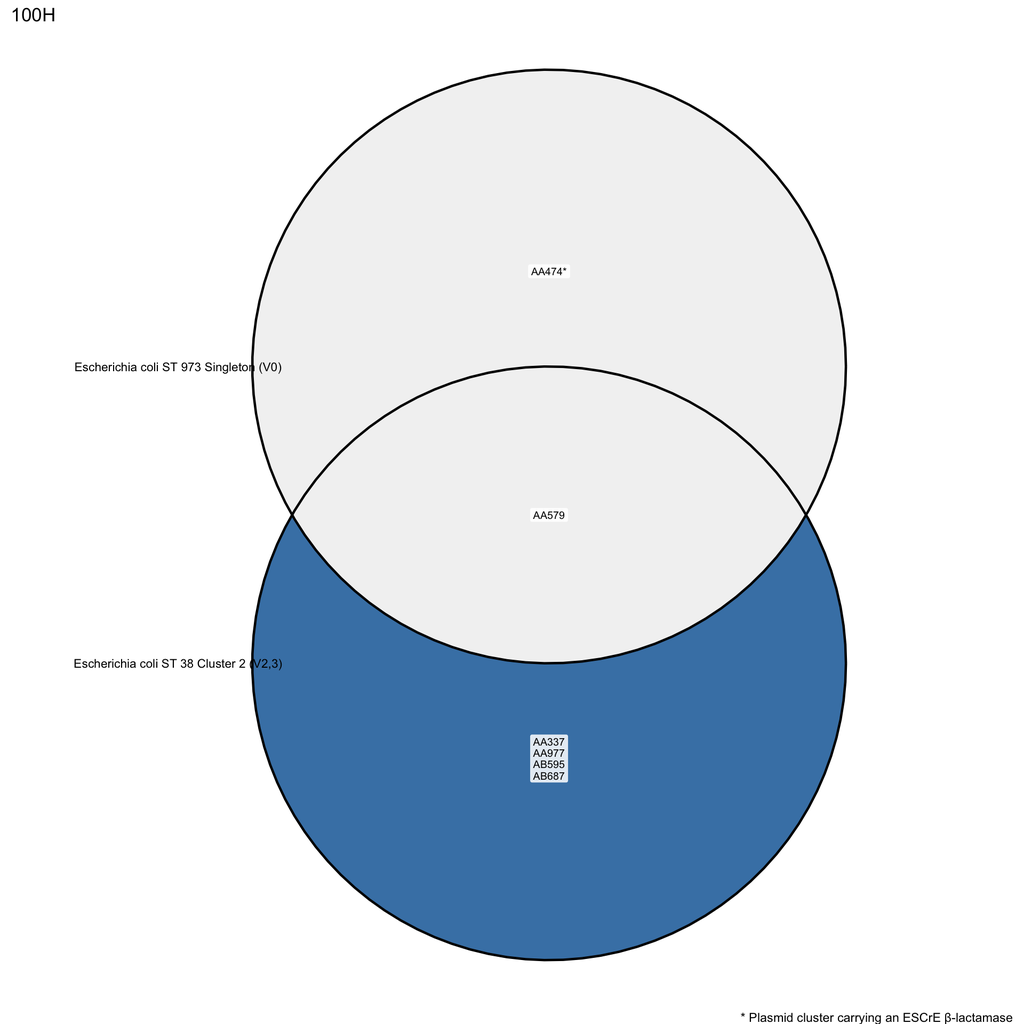

$`169H`

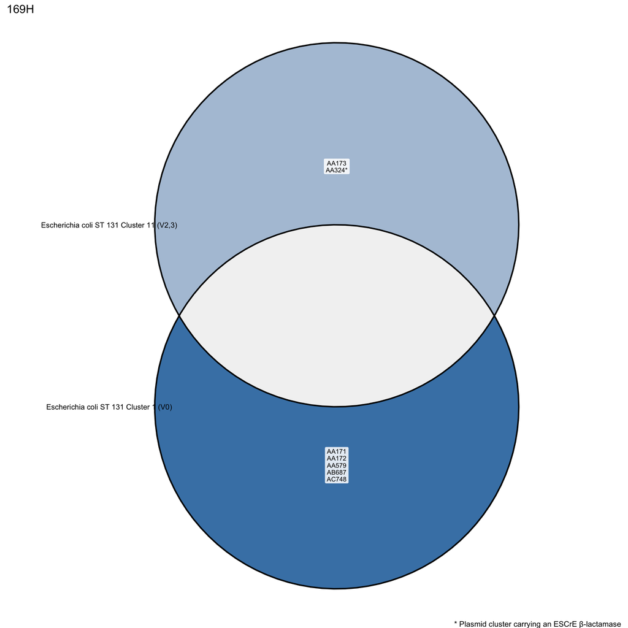

$`1H`

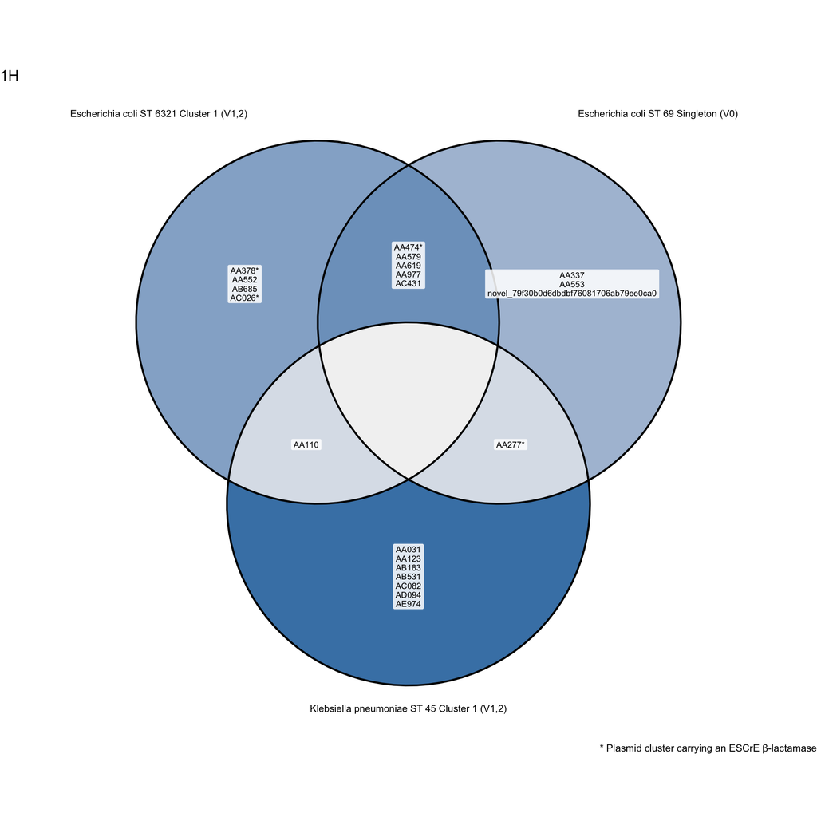

[[1]]

household

genomic_id

Species_ST_cluster

visit

plasmids

secondary_cluster_id

mash_nearest_neighbor

n_strains

bla

ESCrE

sequencing

size

num_contigs

rep_types

relaxase_types

mpf_type

predicted_mobility

mash_neighbor_identification

100H

MERLIN_266

Escherichia coli ST 973 Singleton

0

AA579

AI797

NC_010885

2

FALSE

FALSE

short

4150

1

rep_cluster_1778,rep_cluster_1778

MOBQ

mobilizable

Escherichia coli

100H

MERLIN_150

Escherichia coli ST 38 Cluster 2

2

AA579

AI799

KT693144

2

FALSE

FALSE

short

4159

1

rep_cluster_1778

MOBQ

mobilizable

Escherichia coli

100H

MERLIN_128

Escherichia coli ST 38 Cluster 2

3

AA579

AI799

KT693144

2

FALSE

FALSE

short

4159

1

rep_cluster_1778

MOBQ

mobilizable

Escherichia coli

100H

MERLIN_150

Escherichia coli ST 38 Cluster 2

2

AA337

AI278

CU928148

1

TRUE

FALSE

short

112409

12

IncFIA,IncFIC,IncFIB,rep_cluster_2131

MOBF

MPF_F

conjugative

Escherichia coli UMN026

100H

MERLIN_128

Escherichia coli ST 38 Cluster 2

3

AA337

AI278

CP000244

1

TRUE

FALSE

short

103697

9

IncFIA,IncFIB,rep_cluster_2131

MOBF

MPF_F

conjugative

Escherichia coli UTI89

100H

MERLIN_266

Escherichia coli ST 973 Singleton

0

AA474

AI602

CP023356

1

TRUE

TRUE

short

54805

1

IncI-gamma/K1

MOBP

MPF_I

conjugative

Escherichia coli

100H

MERLIN_150

Escherichia coli ST 38 Cluster 2

2

AA977

AJ479

CP034960

1

FALSE

FALSE

short

5227

1

Col156

MOBQ

mobilizable

Escherichia coli

100H

MERLIN_128

Escherichia coli ST 38 Cluster 2

3

AA977

AJ479

CP034960

1

FALSE

FALSE

short

5200

1

Col156

MOBQ

mobilizable

Escherichia coli

100H

MERLIN_128

Escherichia coli ST 38 Cluster 2

3

AB595

AK439

CP023647

1

FALSE

FALSE

short

8035

2

non-mobilizable

Shigella sonnei

100H

MERLIN_150

Escherichia coli ST 38 Cluster 2

2

AB687

AK567

CP023264

1

FALSE

FALSE

short

1536

1

Col(MG828)

mobilizable

Escherichia coli

100H

MERLIN_128

Escherichia coli ST 38 Cluster 2

3

AB687

AK567

CP023264

1

FALSE

FALSE

short

1536

1

Col(MG828)

mobilizable

Escherichia coli

[[2]]

household

genomic_id

Species_ST_cluster

visit

plasmids

secondary_cluster_id

mash_nearest_neighbor

n_strains

bla

ESCrE

sequencing

size

num_contigs

rep_types

relaxase_types

mpf_type

predicted_mobility

mash_neighbor_identification

169H

MERLIN_9

Escherichia coli ST 131 Cluster 1

0

AA171

AP018574

1

FALSE

FALSE

short

27235

5

MOBF

MPF_F

conjugative

Escherichia coli

169H

MERLIN_9

Escherichia coli ST 131 Cluster 1

0

AA172

CP041531

1

FALSE

FALSE

short

25899

4

IncFIA,IncFII,IncFII

non-mobilizable

Escherichia coli

169H

MERLIN_68

Escherichia coli ST 131 Cluster 11

3

AA173

AH835

CP032425

1

FALSE

FALSE

short

71386

7

IncFIA,IncFIA,IncFIC,IncFIA,IncFIC,IncFIB

non-mobilizable

Escherichia coli

169H

MERLIN_24

Escherichia coli ST 131 Cluster 11

2

AA324

AI218

MK492688

1

TRUE

TRUE

short

119200

11

IncFIA,IncFIA,IncFIC,IncFIA,IncFIC,IncFIB

MOBF

MPF_F

conjugative

Escherichia coli

169H

MERLIN_68

Escherichia coli ST 131 Cluster 11

3

AA324

CP023372

1

FALSE

FALSE

short

42686

2

MOBF

MPF_F

conjugative

Escherichia coli

169H

MERLIN_9

Escherichia coli ST 131 Cluster 1

0

AA579

AI802

CP019024

1

FALSE

FALSE

short

4140

1

rep_cluster_1778

MOBQ

mobilizable

Escherichia coli

169H

MERLIN_9

Escherichia coli ST 131 Cluster 1

0

AB687

AK567

CP023264

1

FALSE

FALSE

short

1593

1

Col(MG828)

mobilizable

Escherichia coli

169H

MERLIN_9

Escherichia coli ST 131 Cluster 1

0

AC748

AM073

CP030115

1

FALSE

FALSE

short

2166

1

Col(BS512)

non-mobilizable

Escherichia coli

[[3]]

household

genomic_id

Species_ST_cluster

visit

plasmids

secondary_cluster_id

mash_nearest_neighbor

n_strains

bla

ESCrE

sequencing

size

num_contigs

rep_types

relaxase_types

mpf_type

predicted_mobility

mash_neighbor_identification

1H

MERLIN_284

Klebsiella pneumoniae ST 45 Cluster 1

1

AA110

AH731

CP036325

2

FALSE

FALSE

short

4047

1

ColRNAI_rep_cluster_1987,rep_cluster_2374

non-mobilizable

Klebsiella pneumoniae

1H

MERLIN_268

Escherichia coli ST 6321 Cluster 1

1

AA110

AH731

CP036325

2

FALSE

FALSE

short

4027

1

ColRNAI_rep_cluster_1987

non-mobilizable

Klebsiella pneumoniae

1H

MERLIN_272

Escherichia coli ST 6321 Cluster 1

2

AA110

AH731

CP036325

2

FALSE

FALSE

short

3605

1

ColRNAI_rep_cluster_1987

non-mobilizable

Klebsiella pneumoniae

1H

MERLIN_288

Escherichia coli ST 69 Singleton

0

AA277

LR134219

2

FALSE

FALSE

short

125791

9

IncFII

MOBF,MOBF

MPF_F

conjugative

Klebsiella aerogenes

1H

MERLIN_284

Klebsiella pneumoniae ST 45 Cluster 1

1

AA277

AI089

CP028817

2

TRUE

TRUE

short

222602

25

IncFIB,IncFII

MOBF,MOBF

MPF_F

conjugative

Klebsiella pneumoniae

1H

MERLIN_271

Klebsiella pneumoniae ST 45 Cluster 1

2

AA277

AI089

CP028817

2

TRUE

TRUE

short

232195

40

IncFIB,IncFII

MPF_F

non-mobilizable

Klebsiella pneumoniae

1H

MERLIN_288

Escherichia coli ST 69 Singleton

0

AA474

AI602

NC_019131

2

TRUE

TRUE

short

103155

9

IncI1/B/O

MOBP

MPF_I

conjugative

Salmonella enterica subsp. enterica serovar Heidelberg

1H

MERLIN_268

Escherichia coli ST 6321 Cluster 1

1

AA474

NC_022267

2

TRUE

FALSE

short

109329

5

IncFIB,IncI-gamma/K1

MOBP

MPF_I

conjugative

Salmonella enterica subsp. enterica serovar Enteritidis

1H

MERLIN_288

Escherichia coli ST 69 Singleton

0

AA579

AI799

KT693144

2

FALSE

FALSE

short

4159

1

rep_cluster_1778

MOBQ

mobilizable

Escherichia coli

1H

MERLIN_268

Escherichia coli ST 6321 Cluster 1

1

AA579

AI802

CP018972

2

FALSE

FALSE

short

6156

2

rep_cluster_1778,rep_cluster_1778

MOBQ

mobilizable

Escherichia coli

1H

MERLIN_272

Escherichia coli ST 6321 Cluster 1

2

AA579

AI802

CP018972

2

FALSE

FALSE

short

7549

2

rep_cluster_1778,rep_cluster_1778

MOBQ,MOBQ

mobilizable

Escherichia coli

1H

MERLIN_288

Escherichia coli ST 69 Singleton

0

AA619

AI862

CP024861

2

FALSE

FALSE

short

33682

2

IncX4

MOBP

MPF_T

conjugative

Escherichia coli

1H

MERLIN_268

Escherichia coli ST 6321 Cluster 1

1

AA619

AI862

CP024861

2

FALSE

FALSE

short

33682

2

IncX4

MOBP

MPF_T

conjugative

Escherichia coli

1H

MERLIN_272

Escherichia coli ST 6321 Cluster 1

2

AA619

AI862

CP024861

2

FALSE

FALSE

short

33682

2

IncX4

MOBP

MPF_T

conjugative

Escherichia coli

1H

MERLIN_288

Escherichia coli ST 69 Singleton

0

AA977

AJ479

CP034960

2

FALSE

FALSE

short

5244

1

Col156

MOBQ

mobilizable

Escherichia coli

1H

MERLIN_268

Escherichia coli ST 6321 Cluster 1

1

AA977

AJ479

CP034960

2

FALSE

FALSE

short

5244

1

Col156

MOBQ

mobilizable

Escherichia coli

1H

MERLIN_272

Escherichia coli ST 6321 Cluster 1

2

AA977

AJ479

CP034960

2

FALSE

FALSE

short

5244

1

rep_cluster_2131

MOBQ

mobilizable

Escherichia coli

1H

MERLIN_288

Escherichia coli ST 69 Singleton

0

AC431

JQ319768

2

FALSE

FALSE

short

13589

2

non-mobilizable

Escherichia coli

1H

MERLIN_268

Escherichia coli ST 6321 Cluster 1

1

AC431

JQ319768

2

FALSE

FALSE

short

10836

1

non-mobilizable

Escherichia coli

1H

MERLIN_284

Klebsiella pneumoniae ST 45 Cluster 1

1

AA031

CP033395

1

TRUE

FALSE

short

28077

3

IncR

non-mobilizable

Klebsiella pneumoniae

1H

MERLIN_284

Klebsiella pneumoniae ST 45 Cluster 1

1

AA123

CP023940

1

FALSE

FALSE

short

1560

1

non-mobilizable

Klebsiella pneumoniae

1H

MERLIN_288

Escherichia coli ST 69 Singleton

0

AA337

AI278

CP014668

1

FALSE

FALSE

short

96871

8

IncFIA,IncFIB,IncFIB

MOBF

MPF_F

conjugative

Escherichia coli

1H

MERLIN_268

Escherichia coli ST 6321 Cluster 1

1

AA378

AI389

CP019188

1

TRUE

TRUE

short

99400

4

IncHI1B

non-mobilizable

Salmonella enterica subsp. enterica serovar Pomona str. ATCC 10729

1H

MERLIN_272

Escherichia coli ST 6321 Cluster 1

2

AA378

AI389

CP019188

1

FALSE

FALSE

short

90497

2

IncHI1B

non-mobilizable

Salmonella enterica subsp. enterica serovar Pomona str. ATCC 10729

1H

MERLIN_272

Escherichia coli ST 6321 Cluster 1

2

AA552

AI745

CP042533

1

FALSE

FALSE

short

47011

4

IncN

MOBF

MPF_T

conjugative

Klebsiella aerogenes

1H

MERLIN_288

Escherichia coli ST 69 Singleton

0

AA553

CP028179

1

FALSE

FALSE

short

17955

6

IncQ1

non-mobilizable

Klebsiella pneumoniae

1H

MERLIN_271

Klebsiella pneumoniae ST 45 Cluster 1

2

AB183

CP000650

1

FALSE

FALSE

short

81218

12

IncR

MPF_F

non-mobilizable

Klebsiella pneumoniae subsp. pneumoniae MGH 78578

1H

MERLIN_284

Klebsiella pneumoniae ST 45 Cluster 1

1

AB531

AK351

CP009878

1

FALSE

FALSE

short

54374

2

rep_cluster_3

non-mobilizable

Klebsiella pneumoniae subsp. pneumoniae

1H

MERLIN_271

Klebsiella pneumoniae ST 45 Cluster 1

2

AB531

AK351

CP009878

1

FALSE

FALSE

short

54298

1

rep_cluster_3

non-mobilizable

Klebsiella pneumoniae subsp. pneumoniae

1H

MERLIN_268

Escherichia coli ST 6321 Cluster 1

1

AB685

AK563

CP023858

1

FALSE

FALSE

short

1611

1

Col(MG828)

mobilizable

Escherichia coli

1H

MERLIN_272

Escherichia coli ST 6321 Cluster 1

2

AB685

AK563

CP023858

1

FALSE

FALSE

short

1611

1

Col(MG828)

mobilizable

Escherichia coli

1H

MERLIN_272

Escherichia coli ST 6321 Cluster 1

2

AC026

CP040923

1

TRUE

TRUE

short

50655

1

IncFIB

MOBP

MPF_I

conjugative

Escherichia coli

1H

MERLIN_284

Klebsiella pneumoniae ST 45 Cluster 1

1

AC082

LS992178

1

FALSE

FALSE

short

6389

2

MPF_T

non-mobilizable

Citrobacter freundii

1H

MERLIN_284

Klebsiella pneumoniae ST 45 Cluster 1

1

AD094

CP015133

1

FALSE

FALSE

short

4506

3

non-mobilizable

Klebsiella pneumoniae

1H

MERLIN_271

Klebsiella pneumoniae ST 45 Cluster 1

2

AE974

MG516910

1

FALSE

FALSE

short

20090

2

non-mobilizable

Escherichia coli

1H

MERLIN_288

Escherichia coli ST 69 Singleton

0

novel_79f30b0d6dbdbf76081706ab79ee0ca0

CP031816

1

FALSE

FALSE

short

5182

1

ColRNAI_rep_cluster_1987

non-mobilizable

Klebsiella pneumoniae

## Restriction to plasmid linked helped distinguish between probable cases of plasmid sharing…

[[1]]

| household | genomic_id | Species_ST_cluster | visit | plasmids | bla_genes | ESCrE_genes | ESCrE_plasmidic_genes | bla_chromosome_genes | ESCrE_chromosome_genes | ESCrE_plasmid_genes | bla_plasmids | ESCrE_plasmids |
| --- | --- | --- | --- | --- | --- | --- | --- | --- | --- | --- | --- | --- |
| 1H | MERLIN_288 | Escherichia coli ST 69 Singleton | 0 | AA277;AA337;AA474;AA553;AA579;AA619;AA977;AC431;novel_79f30b0d6dbdbf76081706ab79ee0ca0 | blaCTX-M-15;blaEC-8* | blaCTX-M-15;blaEC-8* | blaCTX-M-15 | blaEC-8* | blaEC-8* | blaCTX-M-15 | AA474 | AA474 |
| 1H | MERLIN_284 | Klebsiella pneumoniae ST 45 Cluster 1 | 1 | AA031;AA110;AA123;AA277;AB531;AC082;AD094 | blaCTX-M-15;blaSHV-1?;blaTEM-1?*;blaTEM-105?* | blaCTX-M-15 | blaCTX-M-15 |  |  | blaCTX-M-15 | AA031;AA277 | AA277 |
| 1H | MERLIN_268 | Escherichia coli ST 6321 Cluster 1 | 1 | AA110;AA378;AA474;AA579;AA619;AA977;AB685;AC431 | blaCTX-M-15;blaEC-8*;blaTEM-1? | blaCTX-M-15;blaEC-8* | blaCTX-M-15 | blaEC-8* | blaEC-8* | blaCTX-M-15 | AA378;AA474 | AA378 |
| 1H | MERLIN_271 | Klebsiella pneumoniae ST 45 Cluster 1 | 2 | AA277;AB183;AB531;AE974 | blaCTX-M-15;blaTEM-1?*;blaTEM-105?* | blaCTX-M-15 | blaCTX-M-15 |  |  | blaCTX-M-15 | AA277 | AA277 |
| 1H | MERLIN_272 | Escherichia coli ST 6321 Cluster 1 | 2 | AA110;AA378;AA552;AA579;AA619;AA977;AB685;AC026 | blaCTX-M-15;blaEC-8* | blaCTX-M-15;blaEC-8* | blaCTX-M-15 | blaEC-8* | blaEC-8* | blaCTX-M-15 | AC026 | AC026 |
| 1H | MERLIN_173 | Proteus mirabilis ST Unknown Singleton | 3 |  |  |  |  |  |  |  |  |  |

# Conclusion: Increase in detection of ESCrE persistence when considering putative HGT

```
      Plasmid-linked ESCrE
Strain  0  1
     0 14  1
     1  9  7
```